# Assignment 4: The phone company

## Introduction

DM Systems has agreed to supply 500,000 Voip Phones to DISCO Stores in 90 days at fixed price. A key component in the phones is a programmable array logic integrated circuit chip (“PAL chip”), one of which is required in each phone.

DM Systems has bought these chips in the past from an Italian chip manufacturer, IM Chips. However, DM Systems has been approached by a Korean manufacturer, KR Electronics, which is offering a lower price on the chips. This offer is open for only 10 days, and DM Systems must decide whether to buy some or all of the PAL chips from KR. Any chips that DM does not buy from KR will be bought from IM. IM Chips will sell PAL chips to DM for $3.00 per chip in any quantity. KR will accept orders only in multiples of 250,000 PAL chips, and is offering to sell the chips for $2.00 per chip for 250,000 chips, and for $1.50 per chip in quantities of 500,000 or more chips.

## The dumping charge

The situation is complicated by a dumping charge that has been filed by IM Chips against KR. If this charge is upheld by the Italian government, then the KR chips will be subject to an antidumping tax. This case will not be resolved until after the point in time when DM must make the purchase decision. If DM buys the KR chips, these will not be shipped until after the antidumping tax would go into effect and the chips would be subject to the tax. Under the terms offered by KR, DM would have to pay any antidumping tax that is imposed. DM believes there is a 60% chance the antidumping tax will be imposed. If it is imposed, then it is equally likely that the tax will be 50%, 100%, or 200% of the sale price for each PAL chip.

## The decision tree

Draw a decision tree for this decision.

```r
library(yaml)
library(radiant)
library(pander)
library(radiant.model)
tree = yaml.load_file(input = "phones_dtree.yaml")


result =dtree(yl = tree)
plot(result, final = TRUE)
```

[interactive chart not shown]

## Expected value

Using expected value as the decision criterion, determine DM’s preferred ordering alternative for the PAL chips.

```r
EV_IM = -1500000
EV_KRIM_TAX = (-1500000/3)+(-1750000/3)+(-2250000/3)
EV_KRIM_NOTAX = -1250000
EV_KRIM= EV_KRIM_TAX*0.6 + EV_KRIM_NOTAX*0.4
EV_KR_TAX = (-1125000/3)+(-1500000/3)+(-2250000/3)
EV_KRIM_NOTAX = -750000
EV_KR = EV_KR_TAX*0.6 + EV_KRIM_NOTAX*0.4
cat("Il valore atteso della scelta di acquistare solo da IM è",EV_IM,"\n")
```

```
## Il valore atteso della scelta di acquistare solo da IM è -1500000
```

```r
cat("Il valore atteso della scelta di acquistare solo da KR è",EV_KR,"\n")
```

```
## Il valore atteso della scelta di acquistare solo da KR è -1275000
```

```r
cat("Il valore atteso della scelta di acquistare da KR e IM è",EV_KRIM,"\n")
```

```
## Il valore atteso della scelta di acquistare da KR e IM è -1600000
```

## Sensitivity analysis

Perform a sensitivity analysis to evaluate the effect of uncertainties in the process of developing the Decision Tree. In particular consider at least the effect of mistakenly assessing the antidumping tax likelihood.

In reality, it is extremely difficult to define precisely the probability of a certain event. For this reason, a sensitivity analysis must be conducted to understand how the decision would vary with one or more uncertain parameters. In the particular case considered the goal is to calculate how the expected costs can vary with respect to changes in the probability regarding the antidump tax will be imposed.

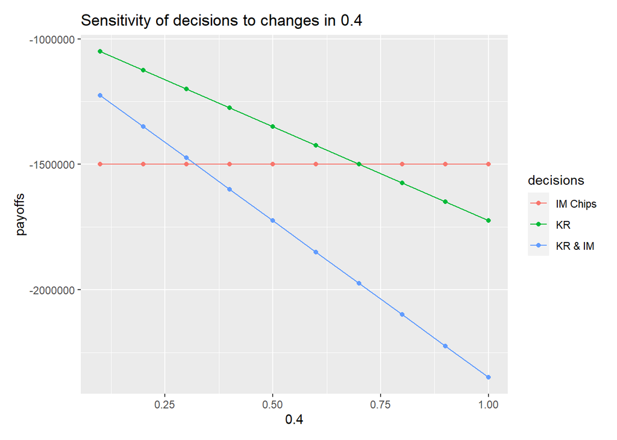

```r
sensitivity(
  result,
  vars = "0.4 0.1 1 0.1;",
  decs = c("IM Chips", "KR & IM", "KR"),
  custom = FALSE)
```

## Utility Function and Certainty Equivalent

Assume that all the information in that exercise still holds, and that DM has an exponential utility function with a risk tolerance of $750,000.

Determine DM’s preferred ordering alternative using this utility function.

```r
utilityFunctionExp <- function(X, R) {
  res <- 1- exp(X/R)
  return(res)
}
profit <- data.frame(IM=c(1500000, 0, 0, 0),
KR=c(1125000,1500000,2250000,750000),
'IM&KR'=c(1500000,1750000,2250000,1250000),
'KR_TAX'=c(1125000,1500000,2250000, 0),
'IM&KR_TAX'=c(1500000,1750000,2250000, 0))

CalcExpectedUtilityFunction <- function(profit, R){
UF1 <- utilityFunctionExp(profit$IM, R)[1]
#####
UF2 <- utilityFunctionExp(profit$KR, R)
UF2_A <- 1/3*(UF2[1]+UF2[2]+UF2[3])
UF2_B <- min(UF2_A, UF2[4])
UF2_C <- 0.6*UF2_B+0.4*UF2[4]
#####
UF3 <- utilityFunctionExp(profit$IM.KR, R)
UF3_A <- 1/3*(UF3[1]+UF3[2]+UF3[3])
UF3_B <- min(UF3_A,UF3[4])
UF3_C <- 0.6*UF3_B+0.4*UF3[4]
#####
UF4 <- utilityFunctionExp(profit$KR_TAX,R)
5
UF4_A <- 1/3*(UF4[1]+UF4[2]+UF4[3])
#####
UF5 <- utilityFunctionExp(profit$IM.KR_TAX,R)
UF5_A <- 1/3*(UF5[1]+UF5[2]+UF5[3])
return (c(IM=UF1, KR=UF2_C, 'IM&KR'=UF3_C,'KR_TAX'=UF4_A,'IM&KR_TAX'=UF5_A))
}
CalcExpectedUtilityFunction(profit, 750000)
```

```
##         IM         KR      IM&KR     KR_TAX  IM&KR_TAX
##  -6.389056  -6.478569  -8.675166  -9.652094 -11.595617
```

The certainty equivalent is the amount that the subject would be willing to receive / pay rather than participate in the lottery.

```r
CertEquivalent = function(EU, R){
  CE = R*ln(1-EU)
  return(CE)
}
CalcBranchCE = function(tree, R){
  CE_vett = CertEquivalent(CalcExpectedUtilityFunction(tree, R), R)
  return(CE_vett[1:3])
}
CalcBranchCE(profit,-750000)
```

```
##      IM      KR   IM&KR
## 1500000  750000 1250000
```

## KR revises the offer

In an effort to attract DM’s order, KR Electronics has revised its offer as follows: At no increase in price, KR will now provide DM with the right to cancel its entire order for a 10% fee after the outcome of the antidumping suit is known. However, KR will not be able to accept any additional orders from DM once the outcome of the suit is known. Thus, for example, if DM has agreed to purchase 250,000 PAL chips from KR at $2.00 per chip, DM can cancel the order by paying $50,000. This ability to cancel the order is potentially of interest to DM because it knows that IM Chips would be able to supply PAL chips after the outcome of the antidumping suit is known in time for DM to fill the DISCO order.

However, DM knows that IM will increase the price of its chips if an antidumping tax is imposed. In particular, if a 50% tax is imposed, then IM will increase its chip price by 15%. If a 100% tax is imposed, then IM will increase its chip price by 20%. Finally, if a 200% tax is imposed, then IM will increase its chip price by 25%.

Assuming that all other information is still valid, determine DM’s preferred alternative for the initial order of PAL chips as well as what DM should do if the antidumping tax is imposed.

```r
tree = yaml.load_file(input = "phones_dtree_2.yaml")


result =dtree(yl = tree)
plot(result, final = TRUE)
```

[interactive chart not shown]

According to the expected value the DM will still prefer to buy all chips from KR electronics. The possibility of cancelling the order from KR electronincs by paying a fee lead the DM to a decreased expected cost since is now more convenient to cancel the order if all chips are bought from KR electronics and a 200% tax will be imposed: in this case there is a save of $300.000$.

## Value of Information

Assume that all the information presented still holds. Using the expected value as the decision criterion, determine the maximum amount that DM should pay for information about whether the antidumping tax will be imposed. Suppose this information can be obtained prior to making the ordering decision.

```r
tree = yaml.load_file(input = "phones_dtree_3.yaml")
```

```r
result =dtree(yl = tree)
plot(result, final = TRUE)
```

[interactive chart not shown]

If the tax will not be imposed, the best option will be to buy all chips from KR electronics, while if the tax will be imposed the best option will be to buy all chips from IM electronics.Those are the only options that will be taken into account, the expected value will be computed between those two values [1.500.000; 750.000].

$EV = 0.6 ∗ 1500000 + 0.4 ∗ 750000 = 1200000$

1.275.000 − 1.200.000 = 75.000$ without the possibility of cancelling the order.

1.215.000 − 1.200.000 = 15.000$ with possibility of cancelling the order.